# M4T3 - Develop Models - Galaxy

# 6 Feature Selection

You will then model with each of these new data sets to determine which method, if any, provides the best model accuracy for this project.

## 6.1 Method 1 - Correlation

```r
rf_FitCORg <- readRDS("rf_FitCORg.rds")

#################
# Predict testSet
#################

# predict with rf
rf_Pred2g <- predict(rf_FitCORg, gtestSetCOR)
rf_Pred2g
```

```
   [1] 5 5 5 5 5 5 5 5 5 5 5 5 5 5 5 5 5 0 5 5 5 5 5 5 5 5 0 2 5 5 5 5 5 5 3 5 3 5 0 3 5 5 5 5 5 5 0 2 4 0 5 5 5 5 5 5 0 5 5 5 5 0 4
  [64] 5 4 5 4 0 5 5 5 0 0 5 5 5 5 5 5 5 5 5 5 5 5 4 5 5 0 5 5 5 5 5 5 5 5 0 5 5 5 5 5 5 5 5 5 5 5 3 5 5 5 5 5 5 5 5 4 5 5 5 5 5 0 0
 [127] 5 0 5 5 5 5 5 5 0 5 5 0 5 5 5 0 5 5 5 5 4 5 5 5 5 5 5 5 5 5 5 5 5 0 5 5 5 4 5 5 5 5 5 5 5 5 5 5 5 4 5 5 5 5 5 5 5 5 5 5 5 0 5
 [190] 5 5 5 5 5 4 5 5 5 5 5 5 5 5 5 5 5 5 5 2 5 5 5 5 5 5 5 0 5 5 5 5 5 5 5 5 5 3 4 5 5 5 5 0 5 4 5 5 5 5 5 5 0 5 5 5 5 5 5 0 5 5 3
 [253] 0 5 5 5 0 5 5 5 5 5 5 5 5 5 5 5 5 5 5 5 5 5 2 5 5 3 5 3 5 0 5 5 5 5 5 5 5 5 5 5 5 5 5 5 5 5 5 5 5 5 3 5 5 5 0 3 5 0 5 5 5 5 5
 [316] 5 5 5 5 3 5 5 5 5 5 5 5 3 5 5 3 3 5 5 5 5 5 5 0 5 5 3 5 5 5 5 5 5 5 0 5 5 5 5 0 5 5 5 5 5 0 5 5 5 3 5 5 0 3 5 5 4 5 5 0 5 5 5
 [379] 5 5 5 5 5 5 5 5 5 5 5 5 5 0 5 5 5 5 5 5 5 5 5 5 5 5 5 5 5 5 5 5 5 3 5 5 3 5 5 0 5 5 5 5 5 5 5 5 5 5 5 5 5 5 5 5 5 5 5 5 5 3 5
 [442] 5 5 5 5 5 0 5 5 0 5 0 4 5 0 5 5 5 5 5 5 5 5 5 5 5 5 0 5 4 5 5 0 5 5 4 5 5 0 5 5 5 5 5 5 3 5 5 5 5 4 5 5 5 0 5 5 5 5 5 0 5 5 5
 [505] 5 5 5 5 5 5 5 4 5 5 5 5 5 5 0 5 5 0 5 5 4 5 5 0 5 5 5 5 5 5 3 5 5 5 5 5 5 5 5 5 5 5 5 5 5 5 5 0 0 5 5 5 5 5 5 5 5 5 5 5 5 5 5
 [568] 5 5 5 5 4 5 5 5 5 4 4 5 5 5 5 5 5 5 5 5 5 5 5 5 5 5 5 5 4 5 5 0 5 0 5 5 5 5 5 5 5 5 4 5 3 5 5 5 5 5 5 5 5 5 5 5 5 0 5 5 5 0 5
 [631] 0 5 5 5 5 0 0 5 0 5 5 5 5 5 5 5 5 5 0 5 5 5 5 5 3 5 5 5 5 5 5 3 5 5 0 5 5 0 5 5 5 5 5 5 5 5 5 3 5 5 5 5 5 5 5 5 5 0 5 5 5 5 3
 [694] 5 5 5 5 5 5 5 5 5 5 5 5 5 5 0 5 5 5 5 5 5 5 5 5 5 5 0 5 5 5 5 5 4 5 0 5 5 5 5 5 5 5 0 5 5 4 5 5 5 5 5 5 5 0 5 3 5 5 5 5 5 3 3
 [757] 5 5 5 5 5 5 0 0 5 5 5 5 5 5 5 5 5 3 5 0 5 5 3 5 5 0 5 5 5 5 5 5 5 5 5 5 5 5 5 5 5 4 5 5 5 5 5 5 5 5 5 5 5 5 3 5 5 0 3 5 5 5 5
 [820] 5 4 5 5 5 5 5 5 5 5 5 5 5 3 2 5 4 3 0 5 0 5 5 5 5 5 5 4 5 4 5 5 4 5 0 5 5 5 5 5 5 5 5 0 5 5 5 5 0 0 5 5 5 5 5 5 5 3 5 5 5 5 5
 [883] 5 5 5 5 5 5 0 5 5 5 0 0 5 5 5 5 5 5 5 5 5 5 5 3 3 5 0 5 0 5 5 5 5 5 5 5 3 5 3 5 5 5 0 5 5 0 5 5 3 5 5 0 5 5 5 5 5 5 5 3 5 5 5
```

[output cut: 48 more lines]

```r
# summarize predictions
summary(rf_Pred2g)
```

```
   0    1    2    3    4    5
 388    0   17  230  144 3111
```

```r
# performance measurement
postResample(rf_Pred2g, gtestSetCOR$iphonesentiment)
```

```
 Accuracy     Kappa
0.7524422 0.5147966
```

```r
# calculate confusion Matrix
cmrfgcor <-confusionMatrix(rf_Pred2g,gtestSetCOR$iphonesentiment)
cmrfgcor
```

```
Confusion Matrix and Statistics

          Reference
Prediction    0    1    2    3    4    5
         0  375    0    0    0    4    9
         1    0    0    0    0    0    0
         2    0    0   17    0    0    0
         3    3    0    2  185    7   33
         4    1    0    1    2  135    5
         5  209  117  116  169  285 2215

Overall Statistics

               Accuracy : 0.7524
                 95% CI : (0.7386, 0.7659)
    No Information Rate : 0.5815
    P-Value [Acc > NIR] : < 2.2e-16

                  Kappa : 0.5148

 Mcnemar's Test P-Value : NA

Statistics by Class:

                     Class: 0 Class: 1 Class: 2 Class: 3 Class: 4 Class: 5
Sensitivity           0.63776  0.00000  0.12500  0.51966  0.31323   0.9792
Specificity           0.99606  1.00000  1.00000  0.98727  0.99740   0.4496
Pos Pred Value        0.96649      NaN  1.00000  0.80435  0.93750   0.7120
Neg Pred Value        0.93918  0.96992  0.96927  0.95328  0.92098   0.9397
Prevalence            0.15116  0.03008  0.03496  0.09152  0.11080   0.5815
Detection Rate        0.09640  0.00000  0.00437  0.04756  0.03470   0.5694
Detection Prevalence  0.09974  0.00000  0.00437  0.05913  0.03702   0.7997
Balanced Accuracy     0.81691  0.50000  0.56250  0.75346  0.65531   0.7144
```

## 6.2 Method 2 - Feature Variance

```r
##########################################
# RF Model - Method 2 - Feature Variance #
##########################################

#nearZeroVar() with saveMetrics = TRUE returns an object containing a table including: frequency ratio, percentage unique, zero variance and near zero variance

gnzvMetrics <- nearZeroVar(iphone_smallmatrix_N, saveMetrics = TRUE)
gnzvMetrics
```

|  | freqRatio | percentUnique | zeroVar | nzv |
| --- | --- | --- | --- | --- |
| iphone | 5.041322 | 0.20812457 | FALSE | FALSE |
| samsunggalaxy | 14.127336 | 0.05395822 | FALSE | FALSE |
| sonyxperia | 44.170732 | 0.03854159 | FALSE | TRUE |
| nokialumina | 497.884615 | 0.02312495 | FALSE | TRUE |
| htcphone | 11.439614 | 0.06937486 | FALSE | FALSE |
| ios | 27.735294 | 0.04624990 | FALSE | TRUE |
| googleandroid | 61.247573 | 0.04624990 | FALSE | TRUE |
| iphonecampos | 10.524697 | 0.23124952 | FALSE | FALSE |
| samsungcampos | 93.625000 | 0.08479149 | FALSE | TRUE |
| sonycampos | 348.729730 | 0.05395822 | FALSE | TRUE |

[output cut: 49 more lines]

```r
# nearZeroVar() with saveMetrics = FALSE returns an vector
gnzv <- nearZeroVar(iphone_smallmatrix_N, saveMetrics = FALSE)
gnzv
```

```
 [1]  3  4  6  7  9 10 11 12 13 14 15 16 17 19 20 21 22 24 25 26 27 29 30 31 32 34 35 36 37 39 40 41 42 44 45 46 47 49 50 51 52 53
[43] 54 55 56 57 58
```

```r
# create a new data set and remove near zero variance features
iphoneNZV <- iphone_smallmatrix_N[,-gnzv]
str(iphoneNZV)
```

```
'data.frame':   12973 obs. of  12 variables:
 $ iphone         : num  -0.203 -0.203 -0.203 -0.203 -0.203 ...
 $ samsunggalaxy  : num  -0.253 -0.253 -0.253 -0.253 -0.253 ...
 $ htcphone       : num  -0.0325 -0.0325 -0.0325 -0.0325 -0.0325 ...
 $ iphonecampos   : num  -0.132 -0.132 -0.132 -0.132 -0.132 ...
 $ iphonecamunc   : num  -0.204 -0.204 -0.204 -0.204 -0.204 ...
 $ iphonedispos   : num  -0.247 -0.247 -0.247 -0.247 -0.247 ...
 $ iphonedisneg   : num  -0.219 -0.219 -0.219 -0.219 -0.219 ...
 $ iphonedisunc   : num  -0.233 -0.233 -0.233 -0.233 -0.233 ...
 $ iphoneperpos   : num  -0.336 0.219 -0.336 0.219 0.219 ...
 $ iphoneperneg   : num  -0.291 -0.291 -0.291 -0.291 -0.291 ...
 $ iphoneperunc   : num  -0.267 -0.267 -0.267 0.625 -0.267 ...
 $ iphonesentiment: Factor w/ 6 levels "0","1","2","3",..: 1 1 1 1 1 5 5 1 1 1 ...
```

```r
##################
# Train/test sets
##################
# set random seed
set.seed(123)

# create the training partition 70 % of total obs
ginTrainingNZV <- createDataPartition(iphoneNZV$iphonesentiment, p=0.7, list=FALSE)

# create training/testing dataset
gtrainSetNZV <- iphoneNZV[ginTrainingNZV,]
gtestSetNZV <- iphoneNZV[-ginTrainingNZV,]

# verify number of obs
nrow(gtrainSetNZV)
```

```
[1] 9083
```

```r
nrow(gtestSetNZV)
```

```
[1] 3890
```

```r
################
# Train control
################

# set 5 fold cross validation
fitControl <- trainControl(method = "cv", number = 5)

# train/fit
set.seed(123)
grf_FitNZV <- train(iphonesentiment~., data=gtrainSetNZV, method="rf", trControl=fitControl, metric = "Kappa",tuneLength=5)
grf_FitNZV
```

```
Random Forest

9083 samples
  11 predictor
   6 classes: '0', '1', '2', '3', '4', '5'

No pre-processing
Resampling: Cross-Validated (5 fold)
Summary of sample sizes: 7266, 7266, 7265, 7268, 7267
Resampling results across tuning parameters:

  mtry  Accuracy   Kappa
   2    0.7592212  0.5254800
   4    0.7586708  0.5285042
   6    0.7559181  0.5260546
   8    0.7527251  0.5219825
  11    0.7479901  0.5160288

Kappa was used to select the optimal model using the largest value.
The final value used for the model was mtry = 4.
```

```r
# Save the Model #
saveRDS(grf_FitNZV, "grf_FitNZV.rds")

# load and name model
grf_FitNZV<- readRDS("grf_FitNZV.rds")

#################
# Predict testSet
#################
# predict with rf
rf_Pred3g <- predict(grf_FitNZV, gtestSetNZV)
rf_Pred3g
```

```
   [1] 5 5 5 5 5 5 5 5 5 5 5 5 5 5 5 5 5 0 5 5 5 3 5 5 5 5 0 0 5 5 5 5 5 5 3 5 5 5 0 5 5 5 5 5 5 5 0 0 4 0 5 5 5 5 5 5 0 5 5 5 5 0 4
  [64] 5 4 5 4 0 5 5 5 0 0 5 5 5 5 3 5 5 5 5 5 5 5 4 5 5 0 5 5 5 5 5 5 5 4 0 3 5 5 5 5 5 5 5 5 5 5 3 5 5 5 5 5 5 5 5 4 5 5 5 5 5 0 0
 [127] 5 0 3 5 5 5 5 5 0 5 5 0 5 5 5 0 5 5 5 5 4 5 5 5 5 5 5 5 5 5 5 5 5 0 5 5 4 4 5 5 5 5 5 5 5 5 5 5 5 4 5 5 5 5 5 5 5 5 5 5 5 0 5
 [190] 5 5 5 5 5 3 5 5 5 5 5 5 5 5 5 5 5 5 5 0 5 5 5 5 5 5 5 0 5 5 5 5 5 5 5 5 5 3 4 5 5 5 5 0 5 4 5 5 5 5 5 5 0 5 5 5 5 0 5 0 5 5 3
 [253] 0 5 5 5 0 5 5 5 5 5 5 5 5 5 5 5 5 5 5 5 5 5 0 5 5 3 5 5 5 0 5 5 5 3 5 5 5 5 5 5 5 5 2 5 5 5 5 5 5 5 3 5 5 5 0 3 5 0 5 5 5 5 5
 [316] 5 5 5 5 5 5 5 5 5 5 5 5 5 5 5 3 3 5 5 5 5 5 5 0 5 5 5 5 4 5 5 5 5 5 0 5 5 5 5 0 5 5 5 5 5 0 5 5 5 3 5 5 0 3 5 5 4 5 5 0 5 5 5
 [379] 5 5 5 5 5 5 5 5 5 5 5 5 5 0 5 5 5 5 5 5 5 5 5 5 5 5 5 5 5 5 5 5 5 5 5 5 5 5 5 0 5 5 5 5 5 5 5 5 5 5 5 5 5 5 5 0 5 5 5 5 5 3 5
 [442] 5 5 5 5 5 0 5 5 5 5 0 4 5 0 5 5 5 5 5 5 5 5 5 5 5 5 0 5 4 5 5 0 5 5 5 5 5 0 5 5 5 5 3 5 3 5 5 5 5 4 5 5 5 0 5 5 5 5 5 0 5 5 5
 [505] 5 5 5 5 5 5 3 4 5 5 5 5 5 5 0 5 5 0 5 5 4 5 5 0 5 5 5 5 5 5 5 5 5 5 5 5 5 5 5 5 5 5 5 5 5 5 5 0 0 5 5 5 5 3 5 5 5 5 5 5 5 5 5
 [568] 5 5 5 5 4 5 5 5 5 4 4 5 5 5 5 5 5 5 5 5 5 5 5 5 5 5 5 5 4 5 5 0 5 0 5 5 5 5 5 5 5 5 4 5 3 5 5 5 5 5 5 5 5 5 5 3 5 0 5 5 5 0 5
 [631] 0 5 5 5 5 0 0 5 0 5 5 5 5 5 5 5 5 5 0 5 5 5 5 5 5 5 5 5 5 5 5 3 5 5 0 5 5 0 5 5 5 5 5 5 5 5 5 3 5 5 5 5 5 5 5 5 5 0 5 5 5 5 3
 [694] 5 5 5 5 5 5 5 5 5 5 5 5 5 5 0 5 5 5 5 5 5 5 5 5 5 5 0 5 5 5 5 5 4 5 0 5 5 5 5 5 5 5 0 5 5 5 5 5 5 5 5 5 5 0 5 5 5 5 5 5 5 3 3
 [757] 5 5 5 5 5 5 0 0 5 5 5 5 5 5 5 5 5 3 5 0 5 5 3 5 5 0 5 5 5 5 5 5 5 5 5 5 5 5 5 5 5 4 5 5 5 5 5 5 5 5 5 5 5 5 5 5 5 0 5 5 3 5 5
 [820] 5 4 5 5 5 5 5 5 5 5 5 5 5 5 0 5 4 3 0 5 0 5 5 5 5 5 5 4 5 5 5 5 4 5 0 5 5 5 5 5 5 5 5 0 5 5 5 5 0 0 5 5 5 5 5 5 5 3 5 5 5 5 5
 [883] 5 5 5 5 5 5 0 5 5 5 0 0 5 5 5 5 5 5 5 5 5 5 5 5 3 5 0 5 0 5 5 5 5 5 4 5 5 5 4 5 5 5 0 5 5 0 5 5 3 5 5 0 5 5 5 5 5 5 5 5 5 5 5
```

[output cut: 48 more lines]

```r
# summarize predictions
summary(rf_Pred3g)
```

```
   0    1    2    3    4    5
 408    0    3  206  151 3122
```

```r
# performance measurement
postResample(rf_Pred3g, gtestSetNZV$iphonesentiment)
```

```
 Accuracy     Kappa
0.7586118 0.5250921
```

```r
# calculate confusion Matrix
cmrfgnzv <-confusionMatrix(rf_Pred3g,gtestSetNZV$iphonesentiment)
cmrfgnzv
```

```
Confusion Matrix and Statistics

          Reference
Prediction    0    1    2    3    4    5
         0  376    0   18    0    5    9
         1    0    0    0    0    0    0
         2    0    1    0    0    0    2
         3    1    0    0  198    4    3
         4    3    0    0    3  137    8
         5  208  116  118  155  285 2240

Overall Statistics

               Accuracy : 0.7586
                 95% CI : (0.7448, 0.772)
    No Information Rate : 0.5815
    P-Value [Acc > NIR] : < 2.2e-16

                  Kappa : 0.5251

 Mcnemar's Test P-Value : NA

Statistics by Class:

                     Class: 0 Class: 1  Class: 2 Class: 3 Class: 4 Class: 5
Sensitivity           0.63946  0.00000 0.0000000  0.55618  0.31787   0.9903
Specificity           0.99031  1.00000 0.9992009  0.99774  0.99595   0.4582
Pos Pred Value        0.92157      NaN 0.0000000  0.96117  0.90728   0.7175
Neg Pred Value        0.93912  0.96992 0.9650116  0.95711  0.92137   0.9714
Prevalence            0.15116  0.03008 0.0349614  0.09152  0.11080   0.5815
Detection Rate        0.09666  0.00000 0.0000000  0.05090  0.03522   0.5758
Detection Prevalence  0.10488  0.00000 0.0007712  0.05296  0.03882   0.8026
Balanced Accuracy     0.81488  0.50000 0.4996004  0.77696  0.65691   0.7243
```

## 6.3 Method 3 - Feature Elimination

```r
#############################################
# RF Model - Method 3 - Feature Elimination #
#############################################

# Let's sample the data before using RFE
set.seed(123)
iphoneSample <- iphone_smallmatrix_N[sample(1:nrow(iphone_smallmatrix_N), 1000, replace=FALSE),]

# Set up rfeControl with randomforest, repeated cross validation and no updates
ctrl <- rfeControl(functions = rfFuncs,
                   method = "cv",
                   repeats = 5,
                   verbose = FALSE)

# Use rfe and omit the response variable (attribute 59 iphonesentiment)
rfeResultsg <- rfe(iphoneSample[,1:58],
                  iphoneSample$iphonesentiment,
                  sizes=(1:58),
                  rfeControl=ctrl)

# Get results
rfeResultsg
```

```
Recursive feature selection

Outer resampling method: Cross-Validated (10 fold)

Resampling performance over subset size:
```

|  | Variables | Accuracy | Kappa | AccuracySD | KappaSD | Selected |
| --- | --- | --- | --- | --- | --- | --- |
| 1 | 1 | 0.6671 | 0.2612 | 0.02421 | 0.06526 |  |
| 2 | 2 | 0.6741 | 0.2956 | 0.02969 | 0.08543 |  |
| 3 | 3 | 0.6831 | 0.3224 | 0.03251 | 0.08874 |  |
| 4 | 4 | 0.7171 | 0.4187 | 0.03255 | 0.08375 |  |
| 5 | 5 | 0.7261 | 0.4446 | 0.01996 | 0.05456 |  |
| 6 | 6 | 0.7322 | 0.4545 | 0.03141 | 0.07141 |  |
| 7 | 7 | 0.7421 | 0.4813 | 0.02456 | 0.05814 |  |
| 8 | 8 | 0.7461 | 0.4881 | 0.03145 | 0.07630 |  |
| 9 | 9 | 0.7612 | 0.5292 | 0.03488 | 0.07588 |  |
| 10 | 10 | 0.7662 | 0.5359 | 0.03291 | 0.07768 |  |

[output cut: 48 more lines]

```
The top 5 variables (out of 18):
   iphone, samsunggalaxy, googleandroid, iphonedispos, iphonedisunc
```

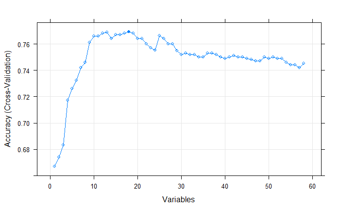

```r
# Save the Model
saveRDS(rfeResultsg, "rfeResultsg.rds")

# load and name model
rfeResultsg<- readRDS("rfeResultsg.rds")

# Plot results
plot(rfeResultsg, type=c("g", "o"))
```

```r
# create new data set with rfe recommended features
iphoneRFE <- iphone_smallmatrix_N[,predictors(rfeResultsg)]

# add the dependent variable to iphoneRFE
iphoneRFE$iphonesentiment <- iphone_smallmatrix_N$iphonesentiment
str(iphoneRFE)
```

```
'data.frame':   12973 obs. of  19 variables:
 $ iphone         : num  -0.203 -0.203 -0.203 -0.203 -0.203 ...
 $ samsunggalaxy  : num  -0.253 -0.253 -0.253 -0.253 -0.253 ...
 $ googleandroid  : num  -0.155 -0.155 -0.155 -0.155 -0.155 ...
 $ iphonedispos   : num  -0.247 -0.247 -0.247 -0.247 -0.247 ...
 $ iphonedisunc   : num  -0.233 -0.233 -0.233 -0.233 -0.233 ...
 $ iphonedisneg   : num  -0.219 -0.219 -0.219 -0.219 -0.219 ...
 $ htcphone       : num  -0.0325 -0.0325 -0.0325 -0.0325 -0.0325 ...
 $ iphoneperpos   : num  -0.336 0.219 -0.336 0.219 0.219 ...
 $ iphonecamneg   : num  -0.246 -0.246 -0.246 -0.246 -0.246 ...
 $ ios            : num  -0.182 -0.182 -0.182 -0.182 -0.182 ...
 $ sonyxperia     : num  -0.14 -0.14 -0.14 -0.14 -0.14 ...
 $ iphoneperunc   : num  -0.267 -0.267 -0.267 0.625 -0.267 ...
 $ iphoneperneg   : num  -0.291 -0.291 -0.291 -0.291 -0.291 ...
 $ iphonecamunc   : num  -0.204 -0.204 -0.204 -0.204 -0.204 ...
 $ htcperpos      : num  -0.11 -0.11 -0.11 -0.11 -0.11 ...
 $ iphonecampos   : num  -0.132 -0.132 -0.132 -0.132 -0.132 ...
 $ htccampos      : num  -0.0708 -0.0708 -0.0708 -0.0708 -0.0708 ...
 $ htcperneg      : num  -0.132 -0.132 -0.132 -0.132 -0.132 ...
 $ iphonesentiment: Factor w/ 6 levels "0","1","2","3",..: 1 1 1 1 1 5 5 1 1 1 ...
```

```r
head(iphone_smallmatrix_N)
```

|  | iphone | samsunggalaxy | sonyxperia | nokialumina | htcphone | ios | googleandroid | iphonecampos | samsungcampos | sonycampos | nokiacampos | htccampos | iphonecamneg | samsungcamneg | sonycamneg | nokiacamneg | htccamneg | iphonecamunc | samsungcamunc | sonycamunc | nokiacamunc | htccamunc | iphonedispos | samsungdispos | sonydispos | nokiadispos | htcdispos | iphonedisneg | samsungdisneg | … |
| --- | --- | --- | --- | --- | --- | --- | --- | --- | --- | --- | --- | --- | --- | --- | --- | --- | --- | --- | --- | --- | --- | --- | --- | --- | --- | --- | --- | --- | --- | --- |
| 1 | -0.2026891 | -0.2533126 | -0.1404243 | -0.04521561 | -0.0324682 | -0.1815276 | -0.1553635 | -0.1322998 | -0.07553119 | -0.06091051 | -0.03013302 | -0.07077802 | -0.2463757 | -0.1032155 | -0.0271757 | -0.03180993 | -0.1335024 | -0.2038985 | -0.09351484 | -0.0423345 | -0.02828426 | -0.09741452 | -0.24728275 | -0.08226598 | -0.03379417 | -0.02686095 | -0.03658502 | -0.2190975 | -0.09100389 | … |
| 2 | -0.2026891 | -0.2533126 | -0.1404243 | -0.04521561 | -0.0324682 | -0.1815276 | -0.1553635 | -0.1322998 | -0.07553119 | -0.06091051 | -0.03013302 | -0.07077802 | -0.2463757 | -0.1032155 | -0.0271757 | -0.03180993 | -0.1335024 | -0.2038985 | -0.09351484 | -0.0423345 | -0.02828426 | -0.09741452 | -0.24728275 | -0.08226598 | -0.03379417 | -0.02686095 | -0.03658502 | -0.2190975 | -0.09100389 | … |
| 3 | -0.2026891 | -0.2533126 | -0.1404243 | -0.04521561 | -0.0324682 | -0.1815276 | -0.1553635 | -0.1322998 | -0.07553119 | -0.06091051 | -0.03013302 | -0.07077802 | -0.2463757 | -0.1032155 | -0.0271757 | -0.03180993 | -0.1335024 | -0.2038985 | -0.09351484 | -0.0423345 | -0.02828426 | -0.09741452 | -0.24728275 | -0.08226598 | -0.03379417 | -0.02686095 | -0.03658502 | -0.2190975 | -0.09100389 | … |
| 4 | -0.2026891 | -0.2533126 | -0.1404243 | -0.04521561 | -0.0324682 | -0.1815276 | -0.1553635 | -0.1322998 | -0.07553119 | -0.06091051 | -0.03013302 | -0.07077802 | -0.2463757 | -0.1032155 | -0.0271757 | -0.03180993 | -0.1335024 | -0.2038985 | -0.09351484 | -0.0423345 | -0.02828426 | -0.09741452 | -0.24728275 | -0.08226598 | -0.03379417 | -0.02686095 | -0.03658502 | -0.2190975 | -0.09100389 | … |
| 5 | -0.2026891 | -0.2533126 | -0.1404243 | -0.04521561 | -0.0324682 | -0.1815276 | -0.1553635 | -0.1322998 | -0.07553119 | -0.06091051 | -0.03013302 | -0.07077802 | -0.2463757 | -0.1032155 | -0.0271757 | -0.03180993 | -0.1335024 | -0.2038985 | -0.09351484 | -0.0423345 | -0.02828426 | -0.09741452 | -0.24728275 | -0.08226598 | -0.03379417 | -0.02686095 | -0.03658502 | -0.2190975 | -0.09100389 | … |
| 6 | 6.8591764 | -0.2533126 | -0.1404243 | -0.04521561 | -0.0324682 | 6.9691541 | -0.1553635 | 0.3245343 | -0.07553119 | -0.06091051 | -0.03013302 | -0.07077802 | 2.9036557 | -0.1032155 | -0.0271757 | -0.03180993 | -0.1335024 | 5.4258442 | -0.09351484 | -0.0423345 | -0.02828426 | -0.09741452 | 0.09751509 | -0.08226598 | -0.03379417 | -0.02686095 | -0.03658502 | 0.8610970 | -0.09100389 | … |

```r
# review outcome
str(iphoneRFE)
```

```
'data.frame':   12973 obs. of  19 variables:
 $ iphone         : num  -0.203 -0.203 -0.203 -0.203 -0.203 ...
 $ samsunggalaxy  : num  -0.253 -0.253 -0.253 -0.253 -0.253 ...
 $ googleandroid  : num  -0.155 -0.155 -0.155 -0.155 -0.155 ...
 $ iphonedispos   : num  -0.247 -0.247 -0.247 -0.247 -0.247 ...
 $ iphonedisunc   : num  -0.233 -0.233 -0.233 -0.233 -0.233 ...
 $ iphonedisneg   : num  -0.219 -0.219 -0.219 -0.219 -0.219 ...
 $ htcphone       : num  -0.0325 -0.0325 -0.0325 -0.0325 -0.0325 ...
 $ iphoneperpos   : num  -0.336 0.219 -0.336 0.219 0.219 ...
 $ iphonecamneg   : num  -0.246 -0.246 -0.246 -0.246 -0.246 ...
 $ ios            : num  -0.182 -0.182 -0.182 -0.182 -0.182 ...
 $ sonyxperia     : num  -0.14 -0.14 -0.14 -0.14 -0.14 ...
 $ iphoneperunc   : num  -0.267 -0.267 -0.267 0.625 -0.267 ...
 $ iphoneperneg   : num  -0.291 -0.291 -0.291 -0.291 -0.291 ...
 $ iphonecamunc   : num  -0.204 -0.204 -0.204 -0.204 -0.204 ...
 $ htcperpos      : num  -0.11 -0.11 -0.11 -0.11 -0.11 ...
 $ iphonecampos   : num  -0.132 -0.132 -0.132 -0.132 -0.132 ...
 $ htccampos      : num  -0.0708 -0.0708 -0.0708 -0.0708 -0.0708 ...
 $ htcperneg      : num  -0.132 -0.132 -0.132 -0.132 -0.132 ...
 $ iphonesentiment: Factor w/ 6 levels "0","1","2","3",..: 1 1 1 1 1 5 5 1 1 1 ...
```

```r
summary(iphoneRFE)
```

```
     iphone        samsunggalaxy     googleandroid      iphonedispos      iphonedisunc      iphonedisneg        htcphone
 Min.   :-0.3792   Min.   :-0.2533   Min.   :-0.1554   Min.   :-0.2473   Min.   :-0.2331   Min.   :-0.2191   Min.   : -0.03247
 1st Qu.:-0.2027   1st Qu.:-0.2533   1st Qu.:-0.1554   1st Qu.:-0.2473   1st Qu.:-0.2331   1st Qu.:-0.2191   1st Qu.: -0.03247
 Median :-0.2027   Median :-0.2533   Median :-0.1554   Median :-0.2473   Median :-0.2331   Median :-0.2191   Median : -0.03247
 Mean   : 0.0000   Mean   : 0.0000   Mean   : 0.0000   Mean   : 0.0000   Mean   : 0.0000   Mean   : 0.0000   Mean   :  0.00000
 3rd Qu.:-0.2027   3rd Qu.:-0.2533   3rd Qu.:-0.1554   3rd Qu.:-0.2473   3rd Qu.:-0.2331   3rd Qu.:-0.2191   3rd Qu.: -0.03247
 Max.   : 7.7419   Max.   :28.2297   Max.   :23.3722   Max.   :22.5094   Max.   :35.3157   Max.   :42.9887   Max.   :113.37932
  iphoneperpos      iphonecamneg          ios            sonyxperia       iphoneperunc      iphoneperneg      iphonecamunc
 Min.   :-0.3362   Min.   :-0.2464   Min.   :-0.1815   Min.   :-0.1404   Min.   :-0.2667   Min.   :-0.2912   Min.   :-0.2039
 1st Qu.:-0.3362   1st Qu.:-0.2464   1st Qu.:-0.1815   1st Qu.:-0.1404   1st Qu.:-0.2667   1st Qu.:-0.2912   1st Qu.:-0.2039
 Median :-0.3362   Median :-0.2464   Median :-0.1815   Median :-0.1404   Median :-0.2667   Median :-0.2912   Median :-0.2039
 Mean   : 0.0000   Mean   : 0.0000   Mean   : 0.0000   Mean   : 0.0000   Mean   : 0.0000   Mean   : 0.0000   Mean   : 0.0000
 3rd Qu.:-0.3362   3rd Qu.:-0.2464   3rd Qu.:-0.1815   3rd Qu.:-0.1404   3rd Qu.:-0.2667   3rd Qu.:-0.2912   3rd Qu.:-0.2039
 Max.   :25.2085   Max.   :32.3040   Max.   : 6.9692   Max.   :46.5705   Max.   :27.3750   Max.   :19.4564   Max.   :35.9873
   htcperpos        iphonecampos       htccampos          htcperneg       iphonesentiment
 Min.   :-0.1101   Min.   :-0.1323   Min.   :-0.07078   Min.   :-0.1316   0:1962
 1st Qu.:-0.1101   1st Qu.:-0.1323   1st Qu.:-0.07078   1st Qu.:-0.1316   1: 390
 Median :-0.1101   Median :-0.1323   Median :-0.07078   Median :-0.1316   2: 454
 Mean   : 0.0000   Mean   : 0.0000   Mean   : 0.00000   Mean   : 0.0000   3:1188
 3rd Qu.:-0.1101   3rd Qu.:-0.1323   3rd Qu.:-0.07078   3rd Qu.:-0.1316   4:1439
 Max.   :55.8116   Max.   :71.1338   Max.   :97.43754   Max.   :35.9283   5:7540
```

```r
##################
# Train/test sets
##################

# set random seed
set.seed(123)

# create the training partition 70 % of total obs
ginTrainingRFE <- createDataPartition(iphoneRFE$iphonesentiment, p=0.7, list=FALSE)

# create training/testing dataset
gtrainSetRFE <- iphoneRFE[ginTrainingRFE,]
gtestSetRFE <- iphoneRFE[-ginTrainingRFE,]

# verify number of obs
nrow(gtrainSetRFE)
```

```
[1] 9083
```

```r
nrow(gtestSetRFE)
```

```
[1] 3890
```

```r
################
# Train control
################

# set 5 fold cross validation
fitControl <- trainControl(method = "cv", number = 5)

# train/fit
set.seed(123)
rf_FitRFEg <- train(iphonesentiment~., data=gtrainSetRFE, method="rf", trControl=fitControl, metric = "Kappa",tuneLength=5)
rf_FitRFEg
```

```
Random Forest

9083 samples
  18 predictor
   6 classes: '0', '1', '2', '3', '4', '5'

No pre-processing
Resampling: Cross-Validated (5 fold)
Summary of sample sizes: 7266, 7266, 7265, 7268, 7267
Resampling results across tuning parameters:

  mtry  Accuracy   Kappa
   2    0.7392914  0.4751717
   6    0.7741933  0.5640166
  10    0.7702296  0.5593232
  14    0.7670359  0.5548326
  18    0.7617504  0.5475156

Kappa was used to select the optimal model using the largest value.
The final value used for the model was mtry = 6.
```

```r
# Save the model
saveRDS(rf_FitRFEg, "rf_FitRFEg.rds")

# load and name model
rf_FitRFEg <- readRDS("rf_FitRFEg.rds")

#################
# Predict testSet
#################
# predict with rf
rf_Pred5g <- predict(rf_FitRFEg, gtestSetRFE)
rf_Pred5g
```

```
   [1] 5 5 5 5 5 5 5 5 5 5 5 5 5 5 5 5 5 0 5 5 5 3 5 5 5 5 0 2 5 5 5 5 5 5 3 5 3 5 0 5 5 5 5 5 5 5 0 2 4 0 5 5 5 5 5 5 0 5 5 5 5 0 4
  [64] 5 4 5 4 0 5 5 5 0 0 5 5 5 5 3 5 5 5 5 5 5 5 4 5 5 0 5 5 5 5 5 5 5 4 0 3 5 5 5 5 5 5 5 5 5 5 3 5 5 5 5 5 5 5 5 4 5 5 5 5 5 0 0
 [127] 5 0 3 5 5 5 5 5 0 5 5 0 5 5 5 0 5 5 5 5 4 5 5 5 5 5 5 5 5 5 5 5 5 0 5 5 4 4 5 5 5 5 5 5 5 5 5 5 5 4 5 5 5 5 5 5 5 5 5 5 5 0 5
 [190] 5 5 5 5 5 4 5 5 5 5 5 5 5 5 5 5 5 5 5 2 5 5 5 5 5 5 5 0 5 5 5 5 5 5 5 5 5 3 4 5 5 5 5 0 5 4 5 5 5 5 5 5 0 5 5 5 5 0 5 0 5 5 3
 [253] 0 5 5 5 0 5 5 5 5 5 5 5 5 5 5 5 5 5 5 5 5 5 2 5 5 3 5 3 5 0 5 5 5 3 5 5 5 5 5 5 5 5 2 5 5 5 5 5 5 5 3 5 5 5 0 3 5 0 5 5 5 5 5
 [316] 5 5 5 5 3 5 5 5 5 5 5 5 3 5 5 3 3 5 5 5 5 5 5 0 5 5 3 5 4 5 5 5 5 5 0 5 5 5 5 0 5 5 5 5 5 0 5 5 5 3 5 5 0 3 5 5 4 5 5 0 5 5 5
 [379] 5 5 5 5 5 5 5 5 5 5 5 5 5 0 5 5 5 5 5 5 5 5 5 5 5 5 5 5 5 5 5 5 5 5 5 5 5 5 5 0 5 5 5 5 5 5 5 5 5 5 5 5 5 5 5 0 5 5 5 5 5 3 5
 [442] 5 5 5 5 5 0 5 5 0 5 0 4 5 0 5 5 5 5 5 5 5 5 5 5 5 5 0 5 4 5 5 0 5 5 4 5 5 0 5 5 5 5 3 5 3 5 5 5 5 4 5 5 5 0 5 5 5 5 5 0 5 5 5
 [505] 5 5 5 5 5 5 3 4 5 5 5 5 5 5 0 5 5 0 5 5 4 5 5 0 5 5 5 5 5 5 3 5 5 5 5 5 5 5 5 5 5 5 5 5 5 5 5 0 0 5 5 5 5 3 5 5 5 5 5 5 5 5 5
 [568] 5 5 5 5 4 5 5 5 5 4 4 5 5 5 5 5 5 5 5 5 5 5 5 5 5 5 5 5 4 5 5 0 5 0 5 5 5 5 5 5 5 5 4 5 3 5 5 5 5 5 5 5 5 5 5 3 5 0 5 5 5 0 5
 [631] 0 5 5 5 5 0 0 5 0 5 5 5 5 5 5 5 5 5 0 5 5 5 5 5 3 5 5 5 5 5 5 3 5 5 0 5 5 0 5 5 5 5 5 5 5 5 5 3 5 5 5 5 5 5 5 5 5 0 5 5 5 5 3
 [694] 5 5 5 5 5 5 5 5 5 5 5 5 5 5 0 5 5 5 5 5 5 5 5 5 5 5 0 5 5 5 5 5 4 5 0 5 5 5 5 5 5 5 0 5 5 5 5 5 5 5 5 5 5 0 5 3 5 5 5 5 5 3 3
 [757] 5 5 5 5 5 5 0 0 5 5 5 5 5 5 5 5 5 3 5 0 5 5 3 5 5 0 5 5 5 5 5 5 5 5 5 5 5 5 5 5 5 4 5 5 5 5 5 5 5 5 5 5 5 5 3 5 5 0 5 5 3 5 5
 [820] 5 4 5 5 5 5 5 5 5 5 5 5 5 5 2 5 4 3 0 5 0 5 5 5 5 5 5 4 5 4 5 5 4 5 0 5 5 5 5 5 5 5 5 0 5 5 5 5 0 0 5 5 5 5 5 5 5 3 5 5 5 5 5
 [883] 5 5 5 5 5 5 0 5 5 5 0 0 5 5 5 5 5 5 5 5 5 5 5 3 3 5 0 5 0 5 5 5 5 5 5 5 3 5 4 5 5 5 0 5 5 0 5 5 3 5 5 0 5 5 5 5 5 5 5 5 5 5 5
```

[output cut: 48 more lines]

```r
# summarize predictions
summary(rf_Pred5g)
```

```
   0    1    2    3    4    5
 393    0   20  245  154 3078
```

```r
# performance measurement
postResample(rf_Pred5g, gtestSetRFE$iphonesentiment)
```

```
 Accuracy     Kappa
0.7753213 0.5631272
```

```r
# calculate confusion Matrix
cmrfeg <-confusionMatrix(rf_Pred5g,gtestSetRFE$iphonesentiment)
cmrfeg
```

```
Confusion Matrix and Statistics

          Reference
Prediction    0    1    2    3    4    5
         0  379    0    1    0    4    9
         1    0    0    0    0    0    0
         2    0    1   17    0    0    2
         3    2    0    0  238    2    3
         4    3    0    1    2  141    7
         5  204  116  117  116  284 2241

Overall Statistics

               Accuracy : 0.7753
                 95% CI : (0.7619, 0.7884)
    No Information Rate : 0.5815
    P-Value [Acc > NIR] : < 2.2e-16

                  Kappa : 0.5631

 Mcnemar's Test P-Value : NA

Statistics by Class:

                     Class: 0 Class: 1 Class: 2 Class: 3 Class: 4 Class: 5
Sensitivity           0.64456  0.00000 0.125000  0.66854  0.32715   0.9907
Specificity           0.99576  1.00000 0.999201  0.99802  0.99624   0.4859
Pos Pred Value        0.96438      NaN 0.850000  0.97143  0.91558   0.7281
Neg Pred Value        0.94023  0.96992 0.969251  0.96763  0.92238   0.9741
Prevalence            0.15116  0.03008 0.034961  0.09152  0.11080   0.5815
Detection Rate        0.09743  0.00000 0.004370  0.06118  0.03625   0.5761
Detection Prevalence  0.10103  0.00000 0.005141  0.06298  0.03959   0.7913
Balanced Accuracy     0.82016  0.50000 0.562100  0.83328  0.66169   0.7383
```

# 7 Feature Engineering

Feature engineering is the art of working with the data so that it can more readily be consumed by machine learning algorithms. Feature engineering includes mutating existing attributes, combining attributes, deconstructing attributes and much more.

In this step we will consider two possibilities:

A- Altering the dependant variable B- Principal Component Analysis

## 7.1 Engineering the Dependant variable

From the previous step you probably saw that several of the dependant variable’s factor levels had very poor Sensitivity and Balanced Accuracy. Do we really need 6 levels to understand positive and negative sentiment? Perhaps combining some of these levels will help increase accuracy and kappa. What if we remapped the values as follows:

1: negative 2: somewhat negative 3: somewhat positive 4: positive

```r
############################################################
# RF Model with RFE and Engineering the Dependant variable #
############################################################
# create a new dataset that will be used for recoding sentiment
iphoneRC <- iphoneRFE
# recode sentiment to combine factor levels 0 & 1 and 4 & 5
iphoneRC$iphonesentiment <- recode(iphoneRFE$iphonesentiment, '0' = 1, '1' = 1, '2' = 2, '3' = 3, '4' = 4, '5' = 4)
# inspect results
summary(iphoneRC)
```

```
     iphone        samsunggalaxy     googleandroid      iphonedispos      iphonedisunc      iphonedisneg        htcphone
 Min.   :-0.3792   Min.   :-0.2533   Min.   :-0.1554   Min.   :-0.2473   Min.   :-0.2331   Min.   :-0.2191   Min.   : -0.03247
 1st Qu.:-0.2027   1st Qu.:-0.2533   1st Qu.:-0.1554   1st Qu.:-0.2473   1st Qu.:-0.2331   1st Qu.:-0.2191   1st Qu.: -0.03247
 Median :-0.2027   Median :-0.2533   Median :-0.1554   Median :-0.2473   Median :-0.2331   Median :-0.2191   Median : -0.03247
 Mean   : 0.0000   Mean   : 0.0000   Mean   : 0.0000   Mean   : 0.0000   Mean   : 0.0000   Mean   : 0.0000   Mean   :  0.00000
 3rd Qu.:-0.2027   3rd Qu.:-0.2533   3rd Qu.:-0.1554   3rd Qu.:-0.2473   3rd Qu.:-0.2331   3rd Qu.:-0.2191   3rd Qu.: -0.03247
 Max.   : 7.7419   Max.   :28.2297   Max.   :23.3722   Max.   :22.5094   Max.   :35.3157   Max.   :42.9887   Max.   :113.37932
  iphoneperpos      iphonecamneg          ios            sonyxperia       iphoneperunc      iphoneperneg      iphonecamunc
 Min.   :-0.3362   Min.   :-0.2464   Min.   :-0.1815   Min.   :-0.1404   Min.   :-0.2667   Min.   :-0.2912   Min.   :-0.2039
 1st Qu.:-0.3362   1st Qu.:-0.2464   1st Qu.:-0.1815   1st Qu.:-0.1404   1st Qu.:-0.2667   1st Qu.:-0.2912   1st Qu.:-0.2039
 Median :-0.3362   Median :-0.2464   Median :-0.1815   Median :-0.1404   Median :-0.2667   Median :-0.2912   Median :-0.2039
 Mean   : 0.0000   Mean   : 0.0000   Mean   : 0.0000   Mean   : 0.0000   Mean   : 0.0000   Mean   : 0.0000   Mean   : 0.0000
 3rd Qu.:-0.3362   3rd Qu.:-0.2464   3rd Qu.:-0.1815   3rd Qu.:-0.1404   3rd Qu.:-0.2667   3rd Qu.:-0.2912   3rd Qu.:-0.2039
 Max.   :25.2085   Max.   :32.3040   Max.   : 6.9692   Max.   :46.5705   Max.   :27.3750   Max.   :19.4564   Max.   :35.9873
   htcperpos        iphonecampos       htccampos          htcperneg       iphonesentiment
 Min.   :-0.1101   Min.   :-0.1323   Min.   :-0.07078   Min.   :-0.1316   Min.   :1.000
 1st Qu.:-0.1101   1st Qu.:-0.1323   1st Qu.:-0.07078   1st Qu.:-0.1316   1st Qu.:3.000
 Median :-0.1101   Median :-0.1323   Median :-0.07078   Median :-0.1316   Median :4.000
 Mean   : 0.0000   Mean   : 0.0000   Mean   : 0.00000   Mean   : 0.0000   Mean   :3.295
 3rd Qu.:-0.1101   3rd Qu.:-0.1323   3rd Qu.:-0.07078   3rd Qu.:-0.1316   3rd Qu.:4.000
 Max.   :55.8116   Max.   :71.1338   Max.   :97.43754   Max.   :35.9283   Max.   :4.000
```

```r
str(iphoneRC)
```

```
'data.frame':   12973 obs. of  19 variables:
 $ iphone         : num  -0.203 -0.203 -0.203 -0.203 -0.203 ...
 $ samsunggalaxy  : num  -0.253 -0.253 -0.253 -0.253 -0.253 ...
 $ googleandroid  : num  -0.155 -0.155 -0.155 -0.155 -0.155 ...
 $ iphonedispos   : num  -0.247 -0.247 -0.247 -0.247 -0.247 ...
 $ iphonedisunc   : num  -0.233 -0.233 -0.233 -0.233 -0.233 ...
 $ iphonedisneg   : num  -0.219 -0.219 -0.219 -0.219 -0.219 ...
 $ htcphone       : num  -0.0325 -0.0325 -0.0325 -0.0325 -0.0325 ...
 $ iphoneperpos   : num  -0.336 0.219 -0.336 0.219 0.219 ...
 $ iphonecamneg   : num  -0.246 -0.246 -0.246 -0.246 -0.246 ...
 $ ios            : num  -0.182 -0.182 -0.182 -0.182 -0.182 ...
 $ sonyxperia     : num  -0.14 -0.14 -0.14 -0.14 -0.14 ...
 $ iphoneperunc   : num  -0.267 -0.267 -0.267 0.625 -0.267 ...
 $ iphoneperneg   : num  -0.291 -0.291 -0.291 -0.291 -0.291 ...
 $ iphonecamunc   : num  -0.204 -0.204 -0.204 -0.204 -0.204 ...
 $ htcperpos      : num  -0.11 -0.11 -0.11 -0.11 -0.11 ...
 $ iphonecampos   : num  -0.132 -0.132 -0.132 -0.132 -0.132 ...
 $ htccampos      : num  -0.0708 -0.0708 -0.0708 -0.0708 -0.0708 ...
 $ htcperneg      : num  -0.132 -0.132 -0.132 -0.132 -0.132 ...
 $ iphonesentiment: num  1 1 1 1 1 4 4 1 1 1 ...
```

```r
# make iphonesentiment a factor
iphoneRC$iphonesentiment <- as.factor(iphoneRC$iphonesentiment)

##################
# Train/test sets
##################

# set random seed
set.seed(123)
ginTrainingRC <- createDataPartition(iphoneRC$iphonesentiment, p=0.7, list=FALSE)
# create training/testing dataset
gtrainSetRC <- iphoneRC[ginTrainingRC,]
gtestSetRC <- iphoneRC[-ginTrainingRC,]

# verify number of obs
nrow(gtrainSetRC)
```

```
[1] 9083
```

```r
nrow(gtestSetRC)
```

```
[1] 3890
```

```r
################
# Train control
################

# set 5 fold cross validation
fitControl <- trainControl(method = "cv", number = 5)

# train/fit

set.seed(123)
rf_FitRCg <- train(iphonesentiment~., data=gtrainSetRC, method="rf", trControl=fitControl, metric = "Kappa",tuneLength=5)
rf_FitRCg
```

```
Random Forest

9083 samples
  18 predictor
   4 classes: '1', '2', '3', '4'

No pre-processing
Resampling: Cross-Validated (5 fold)
Summary of sample sizes: 7266, 7267, 7267, 7267, 7265
Resampling results across tuning parameters:

  mtry  Accuracy   Kappa
   2    0.8182292  0.5235634
   6    0.8501588  0.6265559
  10    0.8485074  0.6254013
  14    0.8461954  0.6213722
  18    0.8432223  0.6156918

Kappa was used to select the optimal model using the largest value.
The final value used for the model was mtry = 6.
```

```r
# Save the model
saveRDS(rf_FitRCg, "rf_FitRCg.rds")

# load and name model
rf_FitRCg <- readRDS("rf_FitRCg.rds")

#################
# Predict testSet
#################
# predict with rf
rf_Pred6g <- predict(rf_FitRCg, gtestSetRC)
rf_Pred6g
```

```
   [1] 4 4 4 4 4 4 4 4 4 4 4 4 4 4 4 1 4 4 4 3 3 4 4 4 4 4 1 2 4 4 4 4 4 4 3 3 4 4 4 4 4 4 4 4 1 4 4 4 1 1 4 4 4 4 1 4 4 4 4 4 1 4 4
  [64] 4 4 3 4 4 4 4 4 4 4 4 1 1 4 4 4 4 4 4 1 3 4 4 4 4 4 4 4 4 4 4 4 4 4 4 4 4 4 1 3 1 4 4 4 4 4 4 1 4 4 4 4 1 4 4 4 1 4 4 4 4 4 4
 [127] 4 4 4 4 4 4 4 4 1 4 4 4 4 4 4 4 4 4 4 4 4 4 4 4 4 4 4 4 4 4 4 4 4 4 4 4 4 4 4 4 2 4 1 4 4 4 4 4 4 4 4 4 4 4 4 4 4 4 4 4 4 4 4
 [190] 4 4 1 4 4 4 4 4 4 4 4 4 4 4 4 3 4 4 4 4 1 4 4 4 4 4 4 4 4 4 4 4 1 4 3 4 4 4 4 4 1 4 4 4 1 4 1 4 4 4 4 4 4 4 2 4 3 4 4 3 4 4 1
 [253] 4 4 3 4 4 4 4 4 4 4 3 4 4 4 4 4 1 4 4 3 4 4 4 4 3 4 4 4 4 4 4 4 4 4 4 3 1 4 4 4 4 4 4 4 1 4 4 4 4 4 4 4 4 4 4 4 3 4 4 4 4 3 4
 [316] 4 1 4 1 4 4 4 4 4 4 4 4 4 4 4 4 4 4 4 4 4 4 4 4 4 4 4 4 4 4 4 1 4 4 1 3 4 4 1 4 1 4 4 4 4 4 4 4 4 4 4 1 4 4 1 4 4 4 4 4 4 1 4
 [379] 4 4 4 3 1 4 4 4 4 1 4 4 4 4 4 4 4 4 1 4 4 4 4 4 4 4 4 4 4 4 4 4 1 4 4 4 4 3 4 4 4 4 4 4 1 1 4 4 1 4 1 4 4 4 4 4 4 4 4 4 4 4 4
 [442] 4 4 4 4 4 4 4 4 3 4 1 4 4 3 4 4 4 4 1 4 1 4 4 4 3 4 4 3 4 4 4 4 4 4 4 4 4 4 4 4 4 4 4 4 1 4 4 4 4 4 4 4 4 1 4 4 1 3 4 4 4 4 4
 [505] 4 4 3 4 4 4 4 1 1 1 4 1 4 4 4 4 4 4 4 4 4 4 3 4 4 1 4 4 4 4 4 4 4 4 1 4 4 4 4 4 4 4 1 4 4 4 4 4 4 3 4 4 4 4 4 4 4 4 4 4 3 4 4
 [568] 4 4 4 4 4 4 1 4 4 4 4 4 4 1 4 4 4 4 4 4 4 4 4 4 4 4 4 4 4 4 4 4 4 1 4 4 4 4 4 4 4 4 3 4 4 4 4 4 4 4 4 4 4 4 4 3 3 4 4 1 4 4 4
 [631] 1 4 4 4 1 4 4 4 4 4 4 4 4 4 4 4 4 4 4 4 4 4 4 4 1 4 4 4 4 4 1 3 4 4 1 4 4 4 4 4 4 4 4 4 4 4 4 4 4 4 4 4 4 4 1 4 4 4 4 4 4 4 4
 [694] 4 4 4 4 4 4 4 4 1 4 4 4 4 4 4 4 4 4 1 3 4 4 4 4 4 1 4 4 4 4 1 4 4 4 4 4 4 4 4 4 4 4 4 4 4 4 4 4 4 4 4 4 4 4 4 1 4 4 4 4 4 1 3
 [757] 3 4 4 4 4 1 4 4 4 1 1 4 4 4 3 1 4 3 4 4 1 4 4 4 4 4 4 4 1 4 4 4 4 4 4 4 4 4 4 4 4 4 4 4 4 4 3 4 4 4 4 1 4 4 4 4 4 3 4 4 4 4 4
 [820] 4 4 4 4 3 4 4 4 4 4 4 4 4 4 4 4 4 4 1 4 1 4 4 4 1 4 4 4 4 4 4 4 4 4 4 4 4 4 4 4 1 4 4 4 4 1 4 4 4 4 4 4 4 4 4 4 4 4 4 4 1 4 4
 [883] 4 4 4 4 4 4 4 4 4 4 4 4 4 4 4 4 4 4 3 4 4 4 3 4 4 4 4 3 4 4 1 4 4 4 4 4 4 4 3 4 3 4 4 4 4 4 3 4 1 4 4 4 4 4 1 4 4 4 4 4 4 1 4
```

[output cut: 48 more lines]

```r
# summarize predictions
summary(rf_Pred6g)
```

```
   1    2    3    4
 407   12  251 3220
```

```r
# performance measurement
postResample(rf_Pred6g, gtestSetRC$iphonesentiment)
```

```
 Accuracy     Kappa
0.8496144 0.6258826
```

```r
# calculate confusion Matrix
cmrcg <-confusionMatrix(rf_Pred6g, gtestSetRC$iphonesentiment, mode="everything")
cmrcg
```

```
Confusion Matrix and Statistics

          Reference
Prediction    1    2    3    4
         1  391    2    1   13
         2    0   12    0    0
         3    3    2  234   12
         4  311  120  121 2668

Overall Statistics

               Accuracy : 0.8496
                 95% CI : (0.838, 0.8607)
    No Information Rate : 0.6923
    P-Value [Acc > NIR] : < 2.2e-16

                  Kappa : 0.6259

 Mcnemar's Test P-Value : < 2.2e-16

Statistics by Class:

                     Class: 1 Class: 2 Class: 3 Class: 4
Sensitivity            0.5546 0.088235  0.65730   0.9907
Specificity            0.9950 1.000000  0.99519   0.5388
Pos Pred Value         0.9607 1.000000  0.93227   0.8286
Neg Pred Value         0.9098 0.968025  0.96647   0.9627
Precision              0.9607 1.000000  0.93227   0.8286
Recall                 0.5546 0.088235  0.65730   0.9907
F1                     0.7032 0.162162  0.77100   0.9024
Prevalence             0.1812 0.034961  0.09152   0.6923
Detection Rate         0.1005 0.003085  0.06015   0.6859
Detection Prevalence   0.1046 0.003085  0.06452   0.8278
Balanced Accuracy      0.7748 0.544118  0.82625   0.7648
```

## 7.2 Principal Component Analysis

Principal Component Analysis (PCA) is a form of feature engineering that removes all of your features and replaces them with mathematical representations of their variance

```r
#####################################################################
# Random Forest Model with PCA and Engineering the Dependent variable
#####################################################################

########### Train/test sets##############

# set random seed
set.seed(123)
# create the training partition 70 % of total obs
inTrainingggpca <- createDataPartition(iphone_smallmatrix$iphonesentiment, p=0.7, list=FALSE)
# create training/testing dataset
gtraining <- iphone_smallmatrix[inTrainingggpca,]
gtesting <- iphone_smallmatrix[-inTrainingggpca,]
# verify number of obs
nrow(gtraining)
```

```
[1] 9083
```

```r
nrow(gtesting)
```

```
[1] 3890
```

```r
########### recode the Dependent variable##############
gtraining$iphonesentiment <- recode(gtraining$iphonesentiment, '0' = 1, '1' = 1, '2' = 2, '3' = 3, '4' = 4, '5' = 4)

gtraining$iphonesentiment <- as.factor(gtraining$iphonesentiment)

gtesting$iphonesentiment <- recode(gtesting$iphonesentiment, '0' = 1, '1' = 1, '2' = 2, '3' = 3, '4' = 4, '5' = 4)

gtesting$iphonesentiment <- as.factor(gtesting$iphonesentiment)

str(gtraining)
```

```
'data.frame':   9083 obs. of  59 variables:
 $ iphone         : int  1 1 1 1 41 1 1 1 1 11 ...
 $ samsunggalaxy  : int  0 0 0 0 0 0 0 0 0 1 ...
 $ sonyxperia     : int  0 0 0 0 0 0 0 0 0 0 ...
 $ nokialumina    : int  0 0 0 0 0 0 0 0 0 0 ...
 $ htcphone       : int  0 0 0 0 0 0 0 0 0 1 ...
 $ ios            : int  0 0 0 0 6 0 0 0 0 0 ...
 $ googleandroid  : int  0 0 0 0 0 0 0 0 1 2 ...
 $ iphonecampos   : int  0 0 0 0 1 1 0 0 0 3 ...
 $ samsungcampos  : int  0 0 0 0 0 0 0 0 0 3 ...
 $ sonycampos     : int  0 0 0 0 0 0 0 0 0 0 ...
 $ nokiacampos    : int  0 0 0 0 0 0 0 0 0 0 ...
 $ htccampos      : int  0 0 0 0 0 0 0 0 0 3 ...
 $ iphonecamneg   : int  0 0 0 0 3 1 0 0 0 5 ...
 $ samsungcamneg  : int  0 0 0 0 0 0 0 0 0 5 ...
```

[output cut: 45 more lines]

```r
### normalize and PCA ####
# data = training and testing from iphoneDF (no feature selection)
# create object containing centered, scaled PCA components from training set
# excluded the dependent variable and set threshold to .95
preprocessParamsgpca <- preProcess(gtraining[,-59], method=c("center", "scale", "pca"), thresh = 0.95)
print(preprocessParamsgpca)
```

```
Created from 9083 samples and 58 variables

Pre-processing:
  - centered (58)
  - ignored (0)
  - principal component signal extraction (58)
  - scaled (58)

PCA needed 25 components to capture 95 percent of the variance
```

```r
# use predict to apply pca parameters, create training, exclude dependant
gtrain.pca <- predict(preprocessParamsgpca, gtraining[,-59])

# add the dependent to training
gtrain.pca$iphonesentiment <- gtraining$iphonesentiment

# use predict to apply pca parameters, create testing, exclude dependant
gtest.pca <- predict(preprocessParamsgpca, gtesting[,-59])

# add the dependent to training
gtest.pca$iphonesentiment <- gtesting$iphonesentiment

# inspect results
str(gtrain.pca)
```

```
'data.frame':   9083 obs. of  26 variables:
 $ PC1            : num  -0.654 -0.589 -0.487 -0.589 0.682 ...
 $ PC2            : num  0.0527 0.0392 0.0119 0.0392 -0.3306 ...
 $ PC3            : num  0.0306 0.0458 0.0662 0.0458 0.4993 ...
 $ PC4            : num  0.586 0.404 0.126 0.404 -4.291 ...
 $ PC5            : num  0.04185 -0.00604 -0.13409 -0.00604 1.31664 ...
 $ PC6            : num  0.16 0.223 0.339 0.223 -8.229 ...
 $ PC7            : num  0.129 0.153 0.272 0.153 -2.494 ...
 $ PC8            : num  0.0735 -0.00624 -0.05677 -0.00624 6.00342 ...
 $ PC9            : num  -0.0399 -0.0149 -0.0147 -0.0149 -0.4857 ...
 $ PC10           : num  -0.023 -0.0635 -0.0563 -0.0635 0.5126 ...
 $ PC11           : num  0.025 0.0339 0.0279 0.0339 -0.39 ...
 $ PC12           : num  -0.228 -0.251 -0.255 -0.251 0.279 ...
 $ PC13           : num  0.0399 0.1191 0.129 0.1191 -0.8882 ...
 $ PC14           : num  -0.1339 -0.1013 -0.0649 -0.1013 0.4777 ...
 $ PC15           : num  -0.01577 0.02925 0.10283 0.02925 0.00576 ...
 $ PC16           : num  -0.0268 0.0271 0.1195 0.0271 0.429 ...
 $ PC17           : num  0.0967 -0.1108 -0.4783 -0.1108 -0.2825 ...
 $ PC18           : num  0.0404 0.0457 -0.0176 0.0457 0.4897 ...
 $ PC19           : num  0.0606 -0.0575 -0.1757 -0.0575 -0.9308 ...
 $ PC20           : num  0.02158 0.01969 0.00326 0.01969 0.09086 ...
 $ PC21           : num  0.0193 -0.0407 0.0812 -0.0407 -0.1312 ...
 $ PC22           : num  0.0612 0.0757 -0.0343 0.0757 0.1398 ...
 $ PC23           : num  0.035 0.028 0.0274 0.028 -0.0062 ...
 $ PC24           : num  -0.0211 -0.0213 0.0477 -0.0213 -0.0741 ...
 $ PC25           : num  0.00549 0.03045 -0.08747 0.03045 -0.0269 ...
 $ iphonesentiment: Factor w/ 4 levels "1","2","3","4": 1 1 1 1 4 4 1 1 3 1 ...
```

```r
str(gtest.pca)
```

```
'data.frame':   3890 obs. of  26 variables:
 $ PC1            : num  -0.654 -0.654 -0.654 -0.654 -0.647 ...
 $ PC2            : num  0.0527 0.0527 0.0527 0.0527 0.0492 ...
 $ PC3            : num  0.0306 0.0306 0.0306 0.0306 0.0345 ...
 $ PC4            : num  0.586 0.586 0.586 0.586 0.564 ...
 $ PC5            : num  0.0418 0.0418 0.0418 0.0418 0.0513 ...
 $ PC6            : num  0.1596 0.1596 0.1596 0.1596 0.0882 ...
 $ PC7            : num  0.129 0.129 0.129 0.129 0.105 ...
 $ PC8            : num  0.0735 0.0735 0.0735 0.0735 0.1296 ...
 $ PC9            : num  -0.0399 -0.0399 -0.0399 -0.0399 -0.0478 ...
 $ PC10           : num  -0.023 -0.023 -0.023 -0.023 -0.011 ...
 $ PC11           : num  0.025 0.025 0.025 0.025 0.0191 ...
 $ PC12           : num  -0.228 -0.228 -0.228 -0.228 -0.222 ...
 $ PC13           : num  0.0399 0.0399 0.0399 0.0399 0.0211 ...
 $ PC14           : num  -0.134 -0.134 -0.134 -0.134 -0.122 ...
 $ PC15           : num  -0.0158 -0.0158 -0.0158 -0.0158 -0.0195 ...
 $ PC16           : num  -0.0268 -0.0268 -0.0268 -0.0268 -0.012 ...
 $ PC17           : num  0.0967 0.0967 0.0967 0.0967 0.093 ...
 $ PC18           : num  0.0404 0.0404 0.0404 0.0404 0.0627 ...
 $ PC19           : num  0.0606 0.0606 0.0606 0.0606 0.0205 ...
 $ PC20           : num  0.0216 0.0216 0.0216 0.0216 0.0271 ...
 $ PC21           : num  0.01931 0.01931 0.01931 0.01931 0.00568 ...
 $ PC22           : num  0.0612 0.0612 0.0612 0.0612 0.0771 ...
 $ PC23           : num  0.035 0.035 0.035 0.035 0.0408 ...
 $ PC24           : num  -0.0211 -0.0211 -0.0211 -0.0211 -0.0244 ...
 $ PC25           : num  0.00549 0.00549 0.00549 0.00549 0.00255 ...
 $ iphonesentiment: Factor w/ 4 levels "1","2","3","4": 1 1 1 1 1 1 1 1 1 1 ...
```

```r
################
# Train control
################

# set 5 fold cross validation
fitControl <- trainControl(method = "cv", number = 5)

# train/fit

set.seed(123)
rf_Fitpcag<- train(iphonesentiment~., data=gtrain.pca, method="rf", trControl=fitControl, metric = "Kappa",tuneLength=5)
rf_Fitpcag
```

```
Random Forest

9083 samples
  25 predictor
   4 classes: '1', '2', '3', '4'

No pre-processing
Resampling: Cross-Validated (5 fold)
Summary of sample sizes: 7266, 7267, 7267, 7267, 7265
Resampling results across tuning parameters:

  mtry  Accuracy   Kappa
   2    0.8400315  0.6054227
   7    0.8416823  0.6086908
  13    0.8415722  0.6083427
  19    0.8411317  0.6073796
  25    0.8402508  0.6050190

Kappa was used to select the optimal model using the largest value.
The final value used for the model was mtry = 7.
```

```r
# Save the model
saveRDS(rf_Fitpcag, "rf_Fitpcag.rds")

# load and name model
rf_Fitpcag <- readRDS("rf_Fitpcag.rds")

#################
# Predict testSet
#################
# predict with rf
rf_Pred7g <- predict(rf_Fitpcag, gtest.pca)
rf_Pred7g
```

```
   [1] 4 4 4 4 4 4 4 4 4 4 4 4 4 4 4 4 4 1 4 4 4 3 4 4 4 4 1 2 4 4 4 4 4 4 1 4 2 4 1 4 4 4 4 4 4 4 1 2 4 1 4 4 4 2 4 4 1 4 4 1 4 1 4
  [64] 4 4 4 4 1 4 4 4 1 1 4 4 4 4 3 4 4 4 4 4 4 4 4 4 4 1 1 4 4 4 4 4 4 4 1 3 4 4 4 4 4 4 4 4 4 4 3 4 4 4 4 4 4 4 4 4 4 4 4 4 4 1 1
 [127] 4 1 3 4 4 4 4 4 1 4 4 1 4 4 4 1 4 4 4 4 4 4 4 4 4 4 4 4 4 4 4 4 4 1 4 4 4 4 4 4 4 4 4 4 4 4 4 4 4 4 4 4 4 4 4 4 4 4 4 4 4 1 4
 [190] 4 4 4 4 4 4 4 4 4 4 4 4 4 4 4 4 4 4 4 2 4 4 4 4 4 4 4 1 4 4 4 4 4 4 4 4 4 3 4 4 4 4 4 1 4 4 4 4 4 4 4 4 1 4 4 4 1 4 4 1 4 4 3
 [253] 1 1 4 4 1 4 4 4 4 4 4 4 4 4 4 4 4 4 4 4 4 4 2 4 1 3 4 3 4 1 4 4 4 3 4 4 4 4 4 4 4 4 2 4 4 4 4 4 4 4 3 4 4 4 1 3 4 1 4 4 4 4 4
 [316] 4 4 4 4 3 4 4 4 4 4 4 4 3 4 4 3 3 4 4 4 4 4 4 1 4 4 3 4 4 4 4 4 4 4 1 4 4 4 4 1 4 4 4 4 4 1 4 4 4 3 4 4 1 3 4 4 4 4 4 1 4 4 4
 [379] 4 4 4 4 4 4 4 4 4 4 4 4 4 1 4 4 4 4 4 4 4 4 4 4 4 4 4 4 1 4 4 4 4 1 4 4 4 4 4 1 4 4 4 4 4 4 4 4 4 4 4 4 4 4 4 1 4 4 4 4 4 3 4
 [442] 4 4 4 2 4 1 4 4 1 4 1 4 4 1 4 4 4 4 4 4 4 4 4 4 4 4 1 4 4 4 4 1 4 4 4 4 4 1 4 4 4 4 3 4 3 4 1 4 4 4 4 4 4 1 4 4 4 4 4 1 4 4 4
 [505] 4 4 4 4 4 4 3 4 4 4 4 4 4 4 1 4 4 1 4 4 4 4 4 1 4 4 4 4 4 4 3 4 4 4 4 4 4 4 4 4 4 4 4 4 4 4 4 1 1 4 4 4 4 3 4 4 4 4 4 4 4 4 4
 [568] 4 4 4 4 4 4 4 4 4 4 4 4 4 4 4 4 4 4 4 4 4 4 4 4 4 4 4 4 4 4 4 1 4 1 4 4 4 4 4 4 4 4 4 4 3 4 4 4 4 4 4 4 4 4 4 3 4 1 4 4 4 1 4
 [631] 1 4 4 4 4 1 1 4 1 4 4 4 4 4 4 4 4 4 1 4 4 4 4 4 3 4 4 4 4 4 4 3 4 4 1 4 4 1 4 4 4 4 4 4 4 4 4 3 4 4 4 4 4 4 4 4 4 1 4 4 4 4 3
 [694] 4 4 4 4 4 4 4 4 4 4 4 4 4 4 1 4 4 4 4 4 4 4 4 4 4 4 1 4 4 4 4 4 4 4 1 4 4 4 4 4 4 4 1 4 4 4 4 4 4 4 4 4 4 1 4 3 4 4 4 4 4 3 3
 [757] 4 4 4 4 4 4 1 1 4 4 4 4 4 4 4 4 4 3 4 1 4 4 3 4 4 4 4 4 4 4 4 4 4 4 4 4 4 4 4 4 4 4 4 4 4 4 4 4 4 4 4 4 4 4 3 4 4 1 4 4 3 4 4
 [820] 4 4 4 4 4 4 4 4 4 4 4 4 4 4 2 4 4 3 1 4 1 4 4 4 4 4 4 4 4 4 4 4 4 4 1 4 4 4 4 4 4 4 4 1 4 4 4 4 1 1 4 4 4 4 4 4 4 3 4 4 4 4 4
 [883] 4 4 4 4 4 4 1 4 4 4 1 1 4 4 4 4 4 4 4 4 4 4 4 3 3 4 1 4 1 4 4 4 4 4 4 4 3 4 3 4 4 4 1 4 4 1 4 4 3 4 4 1 4 4 4 4 4 4 4 4 4 4 4
```

[output cut: 48 more lines]

```r
# summarize predictions
summary(rf_Pred7g)
```

```
   1    2    3    4
 402   29  239 3220
```

```r
# performance measurement
postResample(rf_Pred7g, gtest.pca$iphonesentiment)
```

```
 Accuracy     Kappa
0.8439589 0.6121630
```

```r
# calculate confusion Matrix
options(max.print=10000)
cmrf <-confusionMatrix(rf_Pred7g,gtest.pca$iphonesentiment, mode="everything")
cmrf
```

```
Confusion Matrix and Statistics

          Reference
Prediction    1    2    3    4
         1  376    4    2   20
         2    3   18    0    8
         3    1    0  231    7
         4  325  114  123 2658

Overall Statistics

               Accuracy : 0.844
                 95% CI : (0.8322, 0.8552)
    No Information Rate : 0.6923
    P-Value [Acc > NIR] : < 2.2e-16

                  Kappa : 0.6122

 Mcnemar's Test P-Value : NA

Statistics by Class:

                     Class: 1 Class: 2 Class: 3 Class: 4
Sensitivity           0.53333 0.132353  0.64888   0.9870
Specificity           0.99184 0.997070  0.99774   0.5305
Pos Pred Value        0.93532 0.620690  0.96653   0.8255
Neg Pred Value        0.90568 0.969438  0.96576   0.9478
Precision             0.93532 0.620690  0.96653   0.8255
Recall                0.53333 0.132353  0.64888   0.9870
F1                    0.67931 0.218182  0.77647   0.8990
Prevalence            0.18123 0.034961  0.09152   0.6923
Detection Rate        0.09666 0.004627  0.05938   0.6833
Detection Prevalence  0.10334 0.007455  0.06144   0.8278
Balanced Accuracy     0.76259 0.564711  0.82331   0.7587
```

# 8 Sentiment Analysis in Large Data Matrix

## 8.1 Feature Engineering

```r
########################################
# Feature Engineering with large matrix
########################################

# create new data set with rfe recommended features
iphone_largematrixRFE <- iphone_largematrix_N[,predictors(rfeResultsg)]

# add the dependent variable to iphoneRFE
iphone_largematrixRFE$iphonesentiment <- iphone_largematrix_N$iphonesentiment
str(iphone_largematrixRFE)
```

```
'data.frame':   32226 obs. of  19 variables:
 $ iphone         : num  -0.379 -0.379 -0.379 -0.379 -0.379 ...
 $ samsunggalaxy  : num  -0.253 -0.253 -0.253 -0.253 -0.253 ...
 $ googleandroid  : num  -0.155 -0.155 -0.155 -0.155 -0.155 ...
 $ iphonedispos   : num  -0.247 -0.247 -0.247 -0.247 -0.247 ...
 $ iphonedisunc   : num  -0.233 -0.233 -0.233 -0.233 -0.233 ...
 $ iphonedisneg   : num  -0.219 -0.219 -0.219 -0.219 -0.219 ...
 $ htcphone       : num  -0.0325 -0.0325 -0.0325 -0.0325 -0.0325 ...
 $ iphoneperpos   : num  -0.336 -0.336 -0.336 -0.336 -0.336 ...
 $ iphonecamneg   : num  -0.246 -0.246 -0.246 -0.246 -0.246 ...
 $ ios            : num  -0.182 -0.182 -0.182 -0.182 -0.182 ...
 $ sonyxperia     : num  -0.14 -0.14 -0.14 -0.14 -0.14 ...
 $ iphoneperunc   : num  -0.267 -0.267 -0.267 -0.267 -0.267 ...
 $ iphoneperneg   : num  -0.291 -0.291 -0.291 -0.291 -0.291 ...
 $ iphonecamunc   : num  -0.204 -0.204 -0.204 -0.204 -0.204 ...
 $ htcperpos      : num  -0.11 -0.11 -0.11 -0.11 -0.11 ...
 $ iphonecampos   : num  -0.132 -0.132 -0.132 -0.132 -0.132 ...
 $ htccampos      : num  -0.0708 -0.0708 -0.0708 -0.0708 -0.0708 ...
 $ htcperneg      : num  -0.132 -0.132 -0.132 -0.132 -0.132 ...
 $ iphonesentiment: Factor w/ 0 levels: NA NA NA NA NA NA NA NA NA NA ...
```

## 8.2 Prediction

```r
####################
# Predict new dataSet
####################
# predict with rf
rf_Pred8g <- predict(rf_FitRCg, iphone_largematrixRFE)
rf_Pred8g
```

```
    [1] 1 1 1 1 1 1 1 1 1 1 1 1 1 1 1 4 4 4 4 4 1 4 4 4 1 4 1 1 1 1 4 3 3 3 4 2 4 4 4 1 1 4 4 1 4 1 1 1 1 4 4 4 4 3 3 4 4 3 1 4 3 1
   [63] 4 1 1 4 1 4 3 1 4 3 4 1 2 1 2 1 4 1 3 4 4 2 4 4 1 4 1 4 4 4 4 3 4 4 4 4 4 1 4 2 4 4 4 2 3 3 4 1 1 1 1 1 1 1 1 1 1 1 1 1 1 1
  [125] 1 1 1 1 1 1 1 1 1 1 4 4 4 4 1 4 4 3 4 4 1 3 4 4 1 4 3 4 1 4 4 1 4 1 1 4 4 1 1 1 1 4 4 1 1 4 3 1 4 1 4 4 4 3 4 1 1 1 1 1 1 1
  [187] 1 1 1 1 1 4 4 4 4 2 1 1 1 4 4 4 4 1 4 4 1 4 4 1 1 4 1 2 4 4 1 3 4 4 1 1 4 1 4 1 4 1 1 4 1 4 4 4 4 3 4 4 1 1 1 4 1 4 1 4 4 4
  [249] 1 2 4 4 4 4 1 1 4 3 4 4 3 4 4 4 1 1 1 1 1 4 3 1 4 4 4 4 4 4 1 1 1 4 4 1 4 1 4 4 3 4 3 1 4 4 3 4 4 4 4 4 4 4 2 4 1 1 1 1 1 1
  [311] 1 1 1 1 1 1 1 1 1 1 1 1 1 1 1 4 4 4 1 1 4 4 1 4 4 3 2 3 4 4 4 4 1 3 1 4 4 4 4 1 1 4 3 1 4 4 4 3 4 4 4 4 4 4 1 1 4 4 4 4 4 4
  [373] 4 2 4 4 4 4 2 4 4 1 4 1 4 1 3 4 4 4 4 4 4 1 4 4 4 3 4 2 1 4 4 4 4 4 4 4 4 2 4 4 4 4 2 4 2 3 4 1 1 1 1 4 4 1 1 1 4 3 1 4 4 4
  [435] 3 1 1 1 1 1 1 1 1 1 1 1 1 1 1 1 1 1 1 1 1 1 4 1 4 4 1 4 4 4 1 1 4 1 4 4 4 4 1 1 3 1 1 4 4 4 1 1 4 4 4 4 4 4 4 4 4 4 4 4 4 4
  [497] 4 1 1 1 2 4 4 4 2 4 4 4 1 1 1 4 3 1 1 4 1 3 4 3 4 1 3 4 4 4 4 3 1 3 3 3 1 1 4 3 3 4 4 1 3 1 4 2 4 1 3 4 3 1 4 4 1 1 3 4 4 1
  [559] 4 3 1 1 4 4 4 1 4 4 4 2 1 1 1 1 1 1 1 1 1 1 1 1 1 1 1 1 1 1 1 1 1 1 4 4 1 4 4 1 4 1 4 4 2 4 4 1 4 4 4 4 4 1 4 3 4 4 4 4 4 4
  [621] 4 4 4 4 1 1 1 2 4 4 4 4 4 1 4 4 1 1 4 1 4 4 1 4 4 1 1 1 4 2 4 4 3 1 4 3 4 4 4 4 4 3 1 4 4 1 4 4 4 4 4 1 4 3 4 1 1 4 4 4 4 4
  [683] 4 1 1 4 4 4 1 4 4 1 4 1 1 1 1 1 1 1 1 1 1 1 1 1 1 1 1 1 1 1 1 1 1 1 3 1 4 4 4 4 1 4 4 1 4 2 4 4 4 3 1 1 3 1 3 4 4 4 4 1 3 1
  [745] 4 1 1 4 3 4 4 4 1 4 1 1 4 4 1 4 4 1 4 4 1 4 1 3 1 4 1 4 2 4 4 4 1 4 4 4 1 4 1 4 4 4 4 4 4 4 4 4 1 4 1 4 3 4 4 4 1 4 4 4 4 4
  [807] 4 1 4 4 4 4 4 1 4 1 4 3 4 1 1 1 1 1 1 1 1 1 1 1 1 1 1 1 1 1 1 1 1 1 1 1 4 4 4 1 1 4 1 4 4 4 3 4 4 4 3 2 1 4 4 4 1 1 1 1 3 4
  [869] 4 3 4 4 3 4 4 4 4 4 4 4 4 3 4 4 4 4 4 1 1 1 4 4 4 4 1 4 2 4 1 4 4 4 4 1 4 2 1 4 1 1 4 4 4 4 4 4 4 4 1 4 3 3 1 4 4 4 4 4 3 1
```

[output cut: 149 more lines]

```r
# summarize predictions
summary(rf_Pred8g)
```

```
    1     2     3     4
13086   892  2470 15778
```

```r
###############
# Save datasets
###############
iphone_largematrixoutput <- iphone_largematrix
iphone_largematrixoutput$iphonesentiment<- rf_Pred8g
write.csv(iphone_largematrixoutput, file = "iphone_largematrixoutput.csv")
```

# 9 Model Recomendation

Based on the outcomes of this modeling process, the following configuration was the most suitable in terms of quality metrics (Kappa and Accuracy).

Algorithm: Random Forest Feature Selection: Recursive Feature Elimination Feature Engineering: Engineering the Dependant variable

```r
### Performance Metrics ###

# Modeling Metrics
ModelFitResultiphone <- resamples(list(C5.0=C5.0_Fitg,rf=rf_Fitg,SVM=svm_Fitg,kknn=kknn_Fitg,gbm=gbm_Fit3g))
# output summary metrics for tuned models
summary(ModelFitResultiphone)
```

```
Call:
summary.resamples(object = ModelFitResultiphone)

Models: C5.0, rf, SVM, kknn, gbm
Number of resamples: 5

Accuracy
          Min.   1st Qu.    Median      Mean   3rd Qu.      Max. NA's
C5.0 0.7588106 0.7717272 0.7719008 0.7721003 0.7771051 0.7809576    0
rf   0.7604626 0.7739274 0.7776555 0.7747433 0.7779614 0.7837094    0
SVM  0.6921806 0.7094111 0.7106711 0.7082448 0.7112948 0.7176665    0
kknn 0.3408590 0.3445239 0.3454345 0.3455907 0.3482094 0.3489268    0
gbm  0.7604626 0.7716015 0.7772277 0.7739724 0.7779614 0.7826087    0

Kappa
          Min.   1st Qu.    Median      Mean   3rd Qu.      Max. NA's
C5.0 0.5260384 0.5567474 0.5567909 0.5566646 0.5689753 0.5747708    0
rf   0.5332433 0.5643788 0.5692890 0.5639683 0.5697177 0.5832126    0
SVM  0.3702155 0.4135621 0.4171559 0.4128397 0.4297168 0.4335481    0
kknn 0.1592297 0.1725171 0.1728369 0.1709909 0.1746377 0.1757329    0
gbm  0.5348906 0.5611594 0.5683854 0.5634556 0.5706953 0.5821471    0
```

```r
# Feature Selection
Featureselectioniphone <- resamples(list(Correlation=rf_FitCORg,NZV=grf_FitNZV,RFE=rf_FitRFEg))
# output summary metrics for feature selection
summary(Featureselectioniphone)
```

```
Call:
summary.resamples(object = Featureselectioniphone)

Models: Correlation, NZV, RFE
Number of resamples: 5

Accuracy
                 Min.   1st Qu.    Median      Mean   3rd Qu.      Max. NA's
Correlation 0.7400881 0.7568757 0.7575758 0.7558061 0.7589433 0.7655476    0
NZV         0.7488987 0.7552255 0.7605944 0.7586708 0.7633462 0.7652893    0
RFE         0.7610132 0.7711771 0.7771051 0.7741933 0.7779614 0.7837094    0

Kappa
                 Min.   1st Qu.    Median      Mean   3rd Qu.      Max. NA's
Correlation 0.4876015 0.5266027 0.5268638 0.5230226 0.5293386 0.5447064    0
NZV         0.5075037 0.5233587 0.5305930 0.5285042 0.5387236 0.5423419    0
RFE         0.5361933 0.5604456 0.5694237 0.5640166 0.5705164 0.5835041    0
```

```r
# Feature Engineering
Featureengineeringiphone <- resamples(list(DV=rf_FitRCg,PCA=rf_Fitpcag))
# output summary metrics for feature engineering
summary(Featureengineeringiphone)
```

```
Call:
summary.resamples(object = Featureengineeringiphone)

Models: DV, PCA
Number of resamples: 5

Accuracy
         Min.   1st Qu.    Median      Mean   3rd Qu.      Max. NA's
DV  0.8436123 0.8463656 0.8514034 0.8501588 0.8531353 0.8562775    0
PCA 0.8331498 0.8370941 0.8437844 0.8416823 0.8458150 0.8485683    0

Kappa
         Min.   1st Qu.    Median      Mean   3rd Qu.      Max. NA's
DV  0.6084917 0.6163912 0.6307717 0.6265559 0.6339023 0.6432225    0
PCA 0.5856448 0.5963707 0.6137682 0.6086908 0.6208780 0.6267926    0
```

End of the document

—— SML ——–